# Project: Investigate a Dataset (TMDb movie data)

## Student Name: Sugam Khetrapal

## Course: Machine Learning Foundation - Udacity

- Introduction
- Data Wrangling
- Exploratory Data Analysis
- Conclusions

## Introduction

**About the dataset**: I have selected the TMDb movie data. It contains information about 10,000 movies collected from The Movie Database (TMDb), including user ratings and revenue. The Movie Database (TMDb) is a community built movie and TV database. Every piece of data has been added dating back to 2008. TMDb's strong international focus and breadth of data is largely unmatched.

**The TMDb Advantage**

> 1. Every year since 2008, the number of contributions to the database has increased. With over 125,000 developers and companies using the platform, TMDb has become a premiere source for metadata.
> 2. Along with extensive metadata for movies, TV shows and people, they also offer one of the best selections of high resolution posters and fan art. On average, over 1,000 images are added every single day.
> 3. TMDb officially supports 39 languages and is used in over 180 countries.

**Questions I Plan on Exploring**

## Data Wrangling

### General Properties

```python
# import statements
import pandas as pd
import numpy as np
import matplotlib.pyplot as plt
import seaborn as sns

# read the dataset
df = pd.read_csv("tmdb-movies.csv")
print(list(df))
```

```
['id', 'imdb_id', 'popularity', 'budget', 'revenue', 'original_title', 'cast', 'homepage', 'director', 'tagline', 'keywords', 'overview', 'runtime', 'genres', 'production_companies', 'release_date', 'vote_count', 'vote_average', 'release_year', 'budget_adj', 'revenue_adj']
```

```python
# having a look at the dataset
print(df.head(3))
```

```
       id    imdb_id  popularity     budget     revenue      original_title  \
0  135397  tt0369610   32.985763  150000000  1513528810      Jurassic World
1   76341  tt1392190   28.419936  150000000   378436354  Mad Max: Fury Road
2  262500  tt2908446   13.112507  110000000   295238201           Insurgent

                                                cast  \
0  Chris Pratt|Bryce Dallas Howard|Irrfan Khan|Vi...
1  Tom Hardy|Charlize Theron|Hugh Keays-Byrne|Nic...
2  Shailene Woodley|Theo James|Kate Winslet|Ansel...

                                         homepage          director  \
0                   http://www.jurassicworld.com/   Colin Trevorrow
1                     http://www.madmaxmovie.com/     George Miller
2  http://www.thedivergentseries.movie/#insurgent  Robert Schwentke

                      tagline      ...       \
0           The park is open.      ...
1          What a Lovely Day.      ...
2  One Choice Can Destroy You      ...

                                            overview runtime  \
0  Twenty-two years after the events of Jurassic ...     124
1  An apocalyptic story set in the furthest reach...     120
2  Beatrice Prior must confront her inner demons ...     119

                                      genres  \
0  Action|Adventure|Science Fiction|Thriller
1  Action|Adventure|Science Fiction|Thriller
2         Adventure|Science Fiction|Thriller

                                production_companies release_date vote_count  \
0  Universal Studios|Amblin Entertainment|Legenda...       6/9/15       5562
1  Village Roadshow Pictures|Kennedy Miller Produ...      5/13/15       6185
2  Summit Entertainment|Mandeville Films|Red Wago...      3/18/15       2480

   vote_average  release_year    budget_adj   revenue_adj
0           6.5          2015  1.379999e+08  1.392446e+09
1           7.1          2015  1.379999e+08  3.481613e+08
2           6.3          2015  1.012000e+08  2.716190e+08

[3 rows x 21 columns]
```

```python
# important statistics about the dataset
df.describe()
```

|  | id | popularity | budget | revenue | runtime | vote_count | vote_average | release_year | budget_adj | revenue_adj |
| --- | --- | --- | --- | --- | --- | --- | --- | --- | --- | --- |
| count | 10866.000000 | 10866.000000 | 1.086600e+04 | 1.086600e+04 | 10866.000000 | 10866.000000 | 10866.000000 | 10866.000000 | 1.086600e+04 | 1.086600e+04 |
| mean | 66064.177434 | 0.646441 | 1.462570e+07 | 3.982332e+07 | 102.070863 | 217.389748 | 5.974922 | 2001.322658 | 1.755104e+07 | 5.136436e+07 |
| std | 92130.136561 | 1.000185 | 3.091321e+07 | 1.170035e+08 | 31.381405 | 575.619058 | 0.935142 | 12.812941 | 3.430616e+07 | 1.446325e+08 |
| min | 5.000000 | 0.000065 | 0.000000e+00 | 0.000000e+00 | 0.000000 | 10.000000 | 1.500000 | 1960.000000 | 0.000000e+00 | 0.000000e+00 |
| 25% | 10596.250000 | 0.207583 | 0.000000e+00 | 0.000000e+00 | 90.000000 | 17.000000 | 5.400000 | 1995.000000 | 0.000000e+00 | 0.000000e+00 |
| 50% | 20669.000000 | 0.383856 | 0.000000e+00 | 0.000000e+00 | 99.000000 | 38.000000 | 6.000000 | 2006.000000 | 0.000000e+00 | 0.000000e+00 |
| 75% | 75610.000000 | 0.713817 | 1.500000e+07 | 2.400000e+07 | 111.000000 | 145.750000 | 6.600000 | 2011.000000 | 2.085325e+07 | 3.369710e+07 |
| max | 417859.000000 | 32.985763 | 4.250000e+08 | 2.781506e+09 | 900.000000 | 9767.000000 | 9.200000 | 2015.000000 | 4.250000e+08 | 2.827124e+09 |

```python
# info about # of columns with missing values
df.info()
len(df.columns)
print(list(df))
print(sum(pd.isnull(df['original_title'])))
```

```
<class 'pandas.core.frame.DataFrame'>
RangeIndex: 10866 entries, 0 to 10865
Data columns (total 21 columns):
id                      10866 non-null int64
imdb_id                 10856 non-null object
popularity              10866 non-null float64
budget                  10866 non-null int64
revenue                 10866 non-null int64
original_title          10866 non-null object
cast                    10790 non-null object
homepage                2936 non-null object
director                10822 non-null object
tagline                 8042 non-null object
keywords                9373 non-null object
overview                10862 non-null object
runtime                 10866 non-null int64
genres                  10843 non-null object
production_companies    9836 non-null object
release_date            10866 non-null object
vote_count              10866 non-null int64
vote_average            10866 non-null float64
release_year            10866 non-null int64
budget_adj              10866 non-null float64
revenue_adj             10866 non-null float64
dtypes: float64(4), int64(6), object(11)
memory usage: 1.7+ MB
['id', 'imdb_id', 'popularity', 'budget', 'revenue', 'original_title', 'cast', 'homepage', 'director', 'tagline', 'keywords', 'overview', 'runtime', 'genres', 'production_companies', 'release_date', 'vote_count', 'vote_average', 'release_year', 'budget_adj', 'revenue_adj']
0
```

## Exploratory Data Analysis

### Q1: Which genres are most popular from year to year?

```
                     1960      1961      1962      1963      1964      1965  \
Adventure        0.753047  1.338265  1.996432  1.398764  0.550490  1.124313
Science Fiction -0.467064 -0.361952 -0.640003 -0.646572 -0.667888 -0.869288
Fantasy         -0.528631 -0.744050 -0.691929 -0.895883 -0.012691 -0.992961
Crime           -0.607773 -0.111525 -0.192078 -0.020849  0.082887 -0.523188
Western          0.705451 -0.588007 -0.266409 -0.863575 -1.009777 -0.527569

                     1966      1967      1968      1969    ...         2006  \
Adventure        0.951448  1.817532  1.534066  1.097634    ...     0.608896
Science Fiction  0.097082 -0.634089  1.452081 -0.710447    ...    -0.285369
Fantasy         -0.585750 -0.706100 -0.055098 -0.771756    ...     0.064256
Crime           -0.034184  0.517043  0.209143  0.593035    ...     0.085715
Western         -0.028313 -0.775331 -0.824684  0.996730    ...    -1.032584

                     2007      2008      2009      2010      2011      2012  \
Adventure        0.520337  0.755137  0.977663  1.027009  0.586530  0.732253
Science Fiction -0.305635  0.082456  0.679288 -0.091894  0.212188  0.189865
Fantasy          0.322410  0.008741  0.178378  0.149189  0.028812  0.081027
Crime            0.302191  0.298300 -0.395319 -0.158512 -0.059809  0.092316
Western         -1.024569 -1.058297 -1.111565 -0.974396 -0.992158 -0.868553

                     2013      2014      2015
Adventure        0.755530  1.174435  1.614759
Science Fiction  0.575138  0.902119  1.231957
Fantasy         -0.182739 -0.108344 -0.320493
Crime            0.347388 -0.219402  0.027262
Western         -0.974491 -0.925887 -0.759302

[5 rows x 56 columns]
```

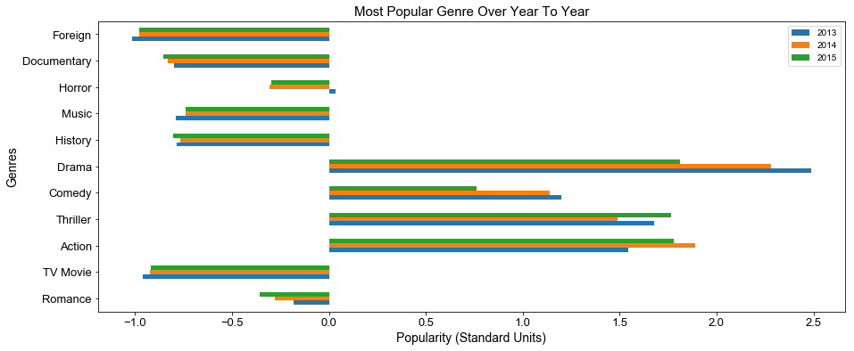

[figure not shown]

```python
#map all the rows of genres in a list.
genre_details = list(map(str,(df['genres'])))
genre = ['Adventure', 'Science Fiction', 'Fantasy', 'Crime', 'Western', 'Family','nan', 'Animation','War','Mystery','Romance','TV Movie','Action', 'Thriller','Comedy','Drama' , 'History', 'Music', 'Horror', 'Documentary', 'Foreign']

#make the numpy array of year and popularity which contain all the rows of release_year and popularity column.
year = np.array(df['release_year'])
popularity = np.array(df['popularity'])

#make a null dataframe which indexs are genres and columns are years.
popularity_df = pd.DataFrame(index = genre, columns = range(1960, 2016))
#change all the values of the dataframe from NAN to zero.
popularity_df = popularity_df.fillna(value = 0.0)

z = 0
for i in genre_details:
    split_genre = list(map(str,i.split('|')))
    popularity_df.loc[split_genre, year[z]] = popularity_df.loc[split_genre, year[z]] + popularity[z]
    z+=1

#calculate the standard deviation for the accurate results.
def calculate_std(x):
    return (x-x.mean())/x.std(ddof=0)

popular_genre = calculate_std(popularity_df)
popular_genre.head()
print(popular_genre.head())

#plot the barh plot of the standardised data.
popular_genre.iloc[10:,53:].plot(kind='barh',figsize = (15,6),fontsize=13)

#setup the title and labels of the plot.
plt.title("Most Popular Genre Over Year To Year",fontsize=15)
plt.xlabel("Popularity (Standard Units)",fontsize=14)
plt.ylabel("Genres",fontsize = 14)
sns.set_style("whitegrid")

#How the popularity of the genre differ year by year.
sns.set_style("whitegrid")
#make a subplot of size 3,3.
fig, ax = plt.subplots(3,3,figsize = (16,10))

#set the title of the subplot.
fig.suptitle('Genre Popularity Over Year To Year',fontsize = 16)

#plot the 'Drama' genre plot see the popularity difference over year to year.
popular_genre.loc['Drama'].plot(label = "Drama",color = '#f67280',ax = ax[0][0],legend=True)

#plot the 'Action' genre plot see the popularity difference over year to year.
popular_genre.loc['Action'].plot(label = "Horror",color='#33FFB5',ax = ax[0][1],legend=True)

#plot the 'Comedy' genre plot see the popularity difference over year to year.
popular_genre.loc['Comedy'].plot(label = "Comedy",color='#fe5f55',ax = ax[0][2],legend=True)

#according to the previous plot the 'Thriller','Science Fiction', 'Romance', 'Music','Adventure' and 'Crime'.
popular_genre.loc['Thriller'].plot(label = "Horror",color='#00818a',ax = ax[1][0],legend=True)
popular_genre.loc['Science Fiction'].plot(label = "Science Fiction",color='#6f6600',ax = ax[1][1],legend=True)
popular_genre.loc['Romance'].plot(label = "Romance",color='#1a2c5b',ax = ax[1][2],legend=True)
popular_genre.loc['Music'].plot(label = "Music",color='#db3b61',ax = ax[2][0],legend=True)
popular_genre.loc['Adventure'].plot(label = "Adventure",color='#08c299',ax = ax[2][1],legend=True)
popular_genre.loc['Crime'].plot(label = "Crime",color='c',ax = ax[2][2],legend=True)
```

### Q2: What kinds of properties are associated with movies that have high revenues?

|  | popularity | budget | revenue | runtime | vote_count | vote_average |
| --- | --- | --- | --- | --- | --- | --- |
| popularity | 1.000000 | 0.545472 | 0.663358 | 0.139033 | 0.800828 | 0.209511 |
| budget | 0.545472 | 1.000000 | 0.734901 | 0.191283 | 0.632702 | 0.081014 |
| revenue | 0.663358 | 0.734901 | 1.000000 | 0.162838 | 0.791175 | 0.172564 |
| runtime | 0.139033 | 0.191283 | 0.162838 | 1.000000 | 0.163278 | 0.156835 |
| vote_count | 0.800828 | 0.632702 | 0.791175 | 0.163278 | 1.000000 | 0.253823 |
| vote_average | 0.209511 | 0.081014 | 0.172564 | 0.156835 | 0.253823 | 1.000000 |

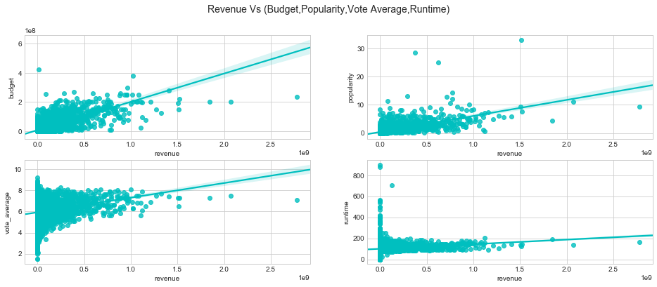

```python
info = pd.DataFrame(df['revenue'].sort_values(ascending=False))
data_set = ['id','popularity','budget','original_title','cast','director','runtime','genres','vote_average','release_year']
for i in data_set:
    info[i] = df[i]
info.head(3)

fig, axes = plt.subplots(2,2,figsize = (16,6))
fig.suptitle("Revenue Vs (Budget,Popularity,Vote Average,Runtime)",fontsize=14)
#info.plot(x = ['revenue'],y = ['budget'],kind = "scatter",ax = axes[0][0])
sns.regplot(x=df['revenue'], y=df['budget'],color='c',ax=axes[0][0])
sns.regplot(x=df['revenue'], y=df['popularity'],color='c',ax=axes[0][1])
sns.regplot(x=df['revenue'], y=df['vote_average'],color='c',ax=axes[1][0])
sns.regplot(x=df['revenue'], y=df['runtime'],color='c',ax=axes[1][1])
#axes.scatter(info['revenue'],info['vote_average'])
sns.set_style("whitegrid")

#correlation between different columns
data_corr = df.corr()
data_corr = data_corr.iloc[1:7,1:7]
data_corr
```

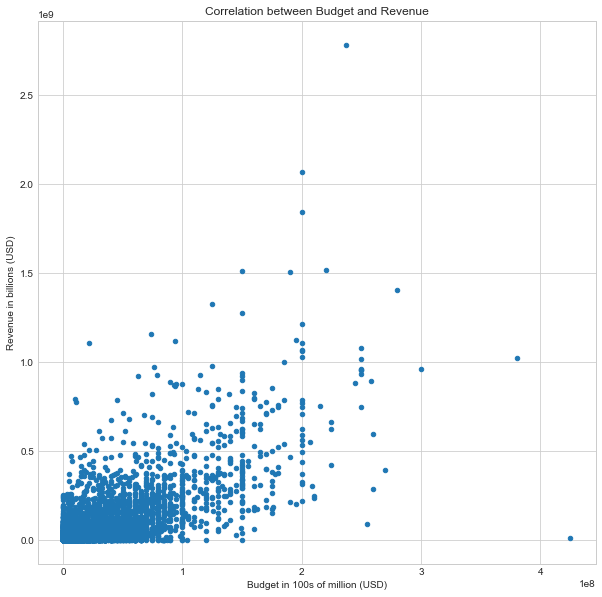

```python
df.plot(x='budget', y='revenue', kind='scatter', figsize=(10,10));
plt.title('Correlation between Budget and Revenue')
# Currency is not mentioned anywhere
# But since we are talking about movie budgets at the Global level, i am assuming the currency is USD
plt.xlabel('Budget in 100s of million (USD)');
plt.ylabel('Revenue in billions (USD)');
```

1. budget vs. revenue -Correlation: 0.73 -There is a good possibility that movies with higher investments result in higher revenues.
2. popularity vs. revenue -Correlation: 0.66 -If the popularity of movie is high then chances are that the revenue of the movie will be high.
3. vote average vs. revenue -correlation: 0.17 -Hence, vote average is not highly correlated to revenue.
4. runtime vs. revenue -correlation: 0.16 -Hence, runtime is not highly correlated to the revenue.

### Q4: How movie budget and popularity have changed over the years?

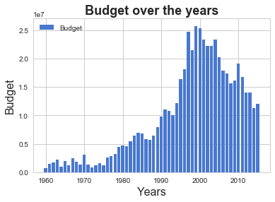

```python
data_movie = df.groupby(['release_year'],as_index=False).mean()
data_movie.head()

sns.set(style="whitegrid")
fig = plt.bar(data_movie["release_year"], data_movie["budget"], color=sns.color_palette("muted",1))

plt.title('Budget over the years', fontsize=18, fontweight='bold')
plt.xlabel('Years', fontsize=16)
plt.ylabel('Budget', fontsize=16)
plt.legend(fig, ['Budget'], loc = "upper left")
plt.show()
```

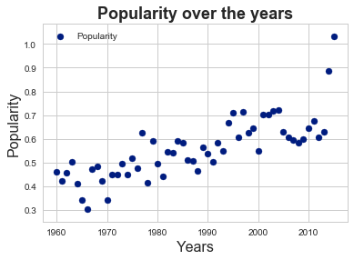

```python
data_movie = df.groupby(['release_year'],as_index=False).mean()

sns.set(style="whitegrid")
plt.scatter(data_movie["release_year"], data_movie["popularity"], color=sns.color_palette("dark",1))
plt.title('Popularity over the years', fontsize=18, fontweight='bold')
plt.xlabel('Years', fontsize=16)
plt.ylabel('Popularity', fontsize=16)
plt.legend(['Popularity'], loc = "upper left")
plt.show()
```

As per the graph we can say that popularity of the movies have increased over time.

```python
#here we get the net profit from the revenue and budget
profit_adj = df['revenue_adj'] - df['budget_adj']
highest_grossing_film_dataframe = pd.DataFrame({'title':df['original_title'], 'profit_adj':profit_adj, 'release_year': df['release_year']})
highest_grossing_film_dataframe = highest_grossing_film_dataframe.sort_values(['profit_adj'], ascending=False)
highest_grossing_film_dataframe.head(10)
```

|  | title | profit_adj | release_year |
| --- | --- | --- | --- |
| 1329 | Star Wars | 2.750137e+09 | 1977 |
| 1386 | Avatar | 2.586237e+09 | 2009 |
| 5231 | Titanic | 2.234714e+09 | 1997 |
| 10594 | The Exorcist | 2.128036e+09 | 1973 |
| 9806 | Jaws | 1.878643e+09 | 1975 |
| 8889 | E.T. the Extra-Terrestrial | 1.767968e+09 | 1982 |
| 3 | Star Wars: The Force Awakens | 1.718723e+09 | 2015 |
| 8094 | The Net | 1.551568e+09 | 1995 |
| 10110 | One Hundred and One Dalmatians | 1.545635e+09 | 1961 |
| 7309 | The Empire Strikes Back | 1.376998e+09 | 1980 |

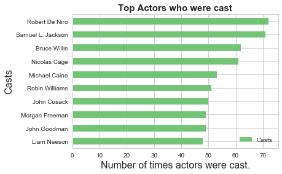

```python
actors_list = df["cast"].str.cat(sep="|").split("|")
actors=pd.Series(actors_list).value_counts(ascending=True)[-10:]

# plotting the horizontal bar graph
sns.set(style="whitegrid")

graph = actors.plot.barh(color=sns.color_palette("Greens",1))
graph.set_title("Top Actors who were cast", fontsize=15, fontweight='bold')
graph.set_xlabel("Number of times actors were cast.", fontsize=16)
graph.set_ylabel("Casts", fontsize=16)
graph.legend(['Casts'], loc = "lower right")
```

```python
print(actors)
```

```
Liam Neeson          48
John Goodman         49
Morgan Freeman       49
John Cusack          50
Robin Williams       51
Michael Caine        53
Nicolas Cage         61
Bruce Willis         62
Samuel L. Jackson    71
Robert De Niro       72
dtype: int64
```

### Q7: Which are the Top 10 Highest Voted Movies?

```python
# sorting movie by 'vote_count'
movies_sorted_by_vote = df.sort_values(['vote_count'], ascending=False)
highest_voted_movies = pd.DataFrame({'title': movies_sorted_by_vote['original_title'], 'vote_count': movies_sorted_by_vote['vote_count'],'release_year':movies_sorted_by_vote['release_year'], 'vote_average':movies_sorted_by_vote['vote_average']})
highest_voted_movies.head(10)
```

|  | title | vote_count | release_year | vote_average |
| --- | --- | --- | --- | --- |
| 1919 | Inception | 9767 | 2010 | 7.9 |
| 4361 | The Avengers | 8903 | 2012 | 7.3 |
| 1386 | Avatar | 8458 | 2009 | 7.1 |
| 2875 | The Dark Knight | 8432 | 2008 | 8.1 |
| 4364 | Django Unchained | 7375 | 2012 | 7.7 |
| 4382 | The Hunger Games | 7080 | 2012 | 6.7 |
| 5425 | Iron Man 3 | 6882 | 2013 | 6.9 |
| 4363 | The Dark Knight Rises | 6723 | 2012 | 7.5 |
| 629 | Interstellar | 6498 | 2014 | 8.0 |
| 4367 | The Hobbit: An Unexpected Journey | 6417 | 2012 | 6.9 |

## Conclusions

There are 21 columns which are 'id', 'imdb_id', 'popularity', 'budget', 'revenue', 'original_title', 'cast', 'homepage', 'director', 'tagline', 'keywords', 'overview', 'runtime', 'genres', 'production_companies', 'release_date', 'vote_count', 'vote_average', 'release_year', 'budget_adj', 'revenue_adj'

Out of these 21 columns: id has no missing values. This column is of no consequence to my investigation. imdb_id had 10 missing values. Every movie which goes into the IMDB database will have an imdb_id randomly (or) sequentially assigned to it. Hence, i do not believe imdb_id is of any consequence to my analysis which is why i did not bother imputing the 10 missing values. popularity has no missing values. budget has no missing values. revenue has no missing values. original_title has no missing values.

homepage had 7930 missing values. Homepage has 7930 values missing out of a total of 10866 values which gives us a miss percentage of a whopping 72.98%. Although this percentage is huge, i don't believe this column has a huge impact on the success of a movie in terms of popularity or revenue. This is why i did not bother imputing the missing values in this column.

director has 44 missing values. This column has 44 values missing out of a total of 10866 values which gives us a miss percentage of a miniscule 0.40%. Since the percentage is negligible, i decided not to impute it.

tagline has 2824 missing values. This column has 2824 values missing out of a total of 10866 values which gives us a considerable miss percentage of 25.99%. Although this percentage is considerable, i don't believe this column has a huge impact on the success of a movie in terms of popularity or revenue. This is why i did not bother imputing the missing values in this column.

keywords has 1493 missing values. This column has 1493 values missing out of a total of 10866 values which gives a miss percentage of 13.74%. Even if the keywords column is missing values, it will not deter people from going out to watch a movie. Column Ignored.

overview has 4 missing values. This column has 4 values missing out of a total of 10866 values which gives a miss percentage of 0.04%. Even if the overview is missing, it will not deter people from going out to watch a movie. Column Ignored.

runtime has no missing values.

genres has 23 missing values. This column has 23 values missing out of a total of 10866 values which gives a miss percentage of 0.21%. Since the percentage is negligible, i decided not to impute it.

production_companies: This column has 1030 values missing out of a total of 10866 values which gives a miss percentage of 9.48%. Although this percentage is noticeable, i did not impute the missing values of this column. I believe the success of any movie in terms of popularity/user reviews/revenue is majorly dependent on the story of the movie. People may decide to go for a movie if a particular actor is cast in it. I agree these days production_companies (Walt Diney, NetFlix, etc.) have also started attracting people to the movie halls. If I had enough data i would be inclined to do a study on production_companies which are famous but failed to churn out successful movies. This may be my personal bias and if i look deeper into the data led by a more detailed investigation, i might find a relationship between high movie revenues and famous production_companies.

release_date has no missing values. vote_count has no missing values. vote_average has no missing values. release_year has no missing values. budget_adj has no missing values. revenue_adj has no missing values.

I believe the following additional attributes could have helped in determining the success of a movie: Profile of the people who are paying to watch the movie. Profile in terms of Age, Gender, Earning Capacity, Address (whether they are living in expensive or humble locality). Type of job of the moviegoer. In short, the more information we have about the people paying to go for the movies, the more accurately we can predict a movie's success.

Does the investigation distinguish between Correlation and Causation? In my analysis report, i have taken question #3 to talk about Correlation between (revenue and budget), (revenue and popularity), (revenue and vote_average) and (revenue and runtime). I found out that there is a high Correlation between (revenue and budget) and (revenue and popularity). I also found out that there is not considerable Correlation between (revenue and vote_average) and (revenue and runtime). My investigation focuses solely on Correlation and does not talk about Causation. Thanks to my reviewer for rightly pointing out that I should have devoted some time discussing about the causation among these variables. Causation would mean checking whether higher revenue resulted in higher budget (OR) higher budget resulted in higher revenue. Same goes for Revenue and popularity. Whether higher revenue resulted in higher popularity (OR) higher popularity resulted in higher revenue. Finding out the answer to this question would add huge value and provide us with meaningful insights w.r.t this dataset. I am trying to figure out how to do this in python and will add to my report.

Although I am not inferring anything without talking about the possibility of it not being true, i guess if i did a more detailed analysis of the relationship between successful movies and famous production_companies, i would have got a better report with an additional perspective.